# Evaluation N1 -Sujet Exemple 2- Corrigé

Frédérique Leblanc

2023-02-19

## Exercice 1 : avec les données diamantsPurs

Charger les données diamantsPur.csv et les affecter à **diamants**.

*Attention le script Rmd et le fichier de données doivent se trouver dans le même répertoire : celui choisi comme répertoire de travail (Working Directory) dans la session. On utilise* **read.table** *avec les options* **sep** *et* **dec** *si le séparateur dans le fichier lu est différent de la virgule et la décimale autre qu’un “.” qui sont les choix par défaut dans la fonction* **read.table**.

```r
read.table("diamantsPurs.csv",header=T)->diamants
head(diamants)
```

|  | carat | cut | color | clarity | depth | table | price | x | y | z |
| --- | --- | --- | --- | --- | --- | --- | --- | --- | --- | --- |
| 1 | 0.52 | Ideal | E | IF | 61.1 | 57 | 3033 | 5.17 | 5.21 | 3.17 |
| 2 | 0.72 | Premium | H | IF | 58.7 | 59 | 3048 | 5.94 | 5.88 | 3.47 |
| 3 | 0.66 | VeryGood | G | IF | 60.5 | 59 | 3051 | 5.69 | 5.74 | 3.46 |
| 4 | 0.65 | Ideal | H | IF | 61.5 | 55 | 3065 | 5.60 | 5.62 | 3.45 |
| 5 | 0.71 | VeryGood | H | IF | 63.0 | 57 | 3112 | 5.63 | 5.70 | 3.57 |
| 6 | 0.68 | VeryGood | G | IF | 62.7 | 56 | 3143 | 5.56 | 5.60 | 3.50 |

On s’intéresse à la variable **price** pour les diamants de taille idéale (**cut==“Ideal”**). Extraire les prix de ces diamants que l’on affecte à **x**. Calculer ensuite les caratéristiques suivantes :

- taille affectée à **nx**
- moyenne affectée à **mx**
- variance empirique affectée à **vx**
- variance empirique corrigée affectée à **vex**
- écart-types empiriques corrigé affectés à **sdex**
- quartiles affectés à **q1**, **q2**, **q3**
- minimum et maximum affectés à **min** et **max**

*Dans le chunck (“tronçon”) d’instructions R, nommé* **extraction}** *, suivant on extrait l’ échantillon* **x** :

```r
x<-diamants$price[diamants$cut=="Ideal"]
```

*Dans le chunck suivant on calcule les caractéristiques qui permettront de renseigner la table des résumés numériques demandés :*

```r
nx<-length(x);mx=mean(x);vex=var(x);vx=(nx-1)/nx*vex;sdex=sd(x)
min<-quantile(x,prob=0,name=F);max<-quantile(x,prob=1,name=F)
q1<-quantile(x,prob=0.25,name=F);q2<-quantile(x,prob=0.5,name=F)
q3<-quantile(x,prob=0.75,name=F)
```

*Ensuite on éxécute le chunck “table” qui crée un data.frame contenant les résultats demandés et l’affiche* :

```r
data.frame("autour de la moyenne" =c("taille","moyenne","variance empirique",
           "variance empirique corrigée", "ecart-type emp. corrigé"),
           "valeurs"=c(nx,mx,vx,vex,sdex),
           "autour de la médiane"=c("minimum","q25%","q50%","q75%","maximum"),
           "boxplot"=c(min,q1,q2,q3,max))->d
print(d,digits=4)
```

```
##          autour.de.la.moyenne valeurs autour.de.la.médiane boxplot
## 1                      taille      85              minimum    3033
## 2                     moyenne    5446                 q25%    3446
## 3          variance empirique 5439445                 q50%    4184
## 4 variance empirique corrigée 5504200                 q75%    7789
## 5     ecart-type emp. corrigé    2346              maximum    9931
```

2. Commentaire : *Un prix moyen dans cette catégorie beaucoup plus élevé que le prix médian signe d’une répartition non symétrique et un écart entre les deux premiers quartiles bien plus faible qu’entre les deux derniers quartiles. Les prix sont beaucoup plus dispersés au dessus de la médiane qu’en dessous.*

## Exercice 2 : Tracé de la fonction tangeante

1. Tracé de la fonction tangeante sur $]0,2\pi[/ \{ \pi/2,3\pi/2\}$ en noir, avec titres et légendes et ajout des axes et des asymptotes en rouge :

*La fonction tangeante étant discontinue en* $\pi/2$ *et* $3\pi/2$ *il faut effectuer son tracé en trois étapes. On utilise la fonction* **curve** *plusieurs fois de suite : on applique la fonction avec l’option* **add=F** *pour faire en première couche le tracé sur* $[0,1.55[$, *puis avec* **add=T** *on ajoute en seconde couche le tracé sur* $[1.64, 4.65]$ *et pour finir en dernière couche le tracé sur* $[4.75,6.2]$.

*Ensuite on ajoute les axes et les asymptotes avec* **abline**.

**Remarque** : les instructions pour réaliser le graphiques doivent être mises dans un même chunck. Ici on exécutera :

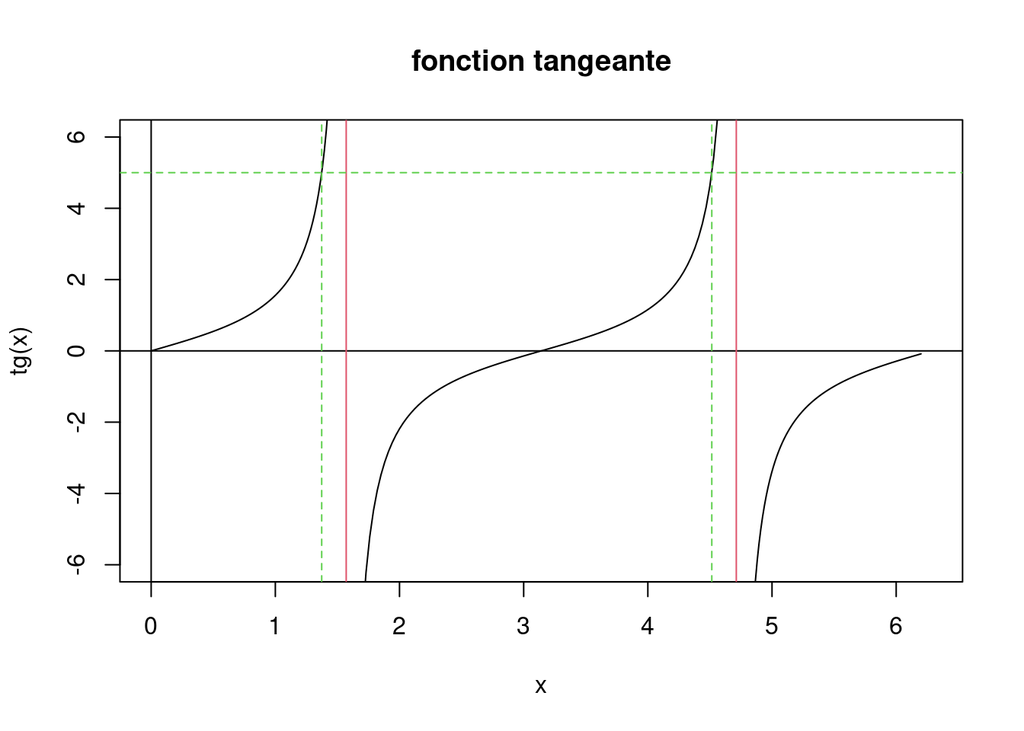

```r
curve(tan, from =0.0, to=1.55, xlim = c(0,2*pi), ylim=c(-6,6),
      main="fonction tangeante", xlab="x", ylab="tg(x)")
curve(tan, from =1.64, to=4.65, add=T)
curve(tan, from =4.75, to=6.2, add=T)
abline(v=0,h=0)                                       #ajout des axes
abline(v=pi/2,col=2);abline(v=3*pi/2,col=2)           #ajout des asymptotes
abline(h=5,lty=2,col=3)                         #aide à la lecture des antécédants de 5
abline(v=atan(5),lty=2,col=3)                   #aide à la lecture des antécédants de 5
abline (v=atan(5)+pi,lty=2,col=3)               #aide à la lecture des antécédants de 5
```

3. *On lit à l’aide des traits en pointillés verts que 5 a deux antécédants dans* $]0,2\pi[$ *qui valent environ* $1.4$ *et* $4.5$. *La fonction tangeante n’est donc pas injective sur* $]0,2\pi[$. *Par contre elle l’est sur* $]0,\pi/2[$ *et sur cet intervalle sa fonction réciproque est calculée avec la fonction* **atan**.